# MMSS311-2 Homework 1

Kevin He

April 17, 2019

Load packages…

```r
library(dplyr)
```

```r
library(ggplot2)
library(broom)
library(tinytex)
```

## Regression Questions

```r
sick_data <- read.csv("sick_data.csv", header = TRUE)
```

1. Using OLS

```r
# Create dummy variable for result
sick_data$result_dummy <- sick_data$result == "Positive"
sick_data$result_dummy[sick_data$result_dummy == TRUE] <- 1
sick_data$result_dummy[sick_data$result_dummy == FALSE] <- 0
# Run OLS
ra_ols <- lm(sick_data$result_dummy ~ sick_data$temp + sick_data$bp)
summary(ra_ols)
```

```
##
## Call:
## lm(formula = sick_data$result_dummy ~ sick_data$temp + sick_data$bp)
##
## Residuals:
##      Min       1Q   Median       3Q      Max
## -0.32785 -0.09918 -0.02229  0.05700  0.82096
##
## Coefficients:
##                  Estimate Std. Error t value Pr(>|t|)
## (Intercept)    -5.2134563  0.5141439  -10.14   <2e-16 ***
## sick_data$temp  0.0628185  0.0050579   12.42   <2e-16 ***
## sick_data$bp   -0.0082865  0.0004702  -17.62   <2e-16 ***
## ---
## Signif. codes:  0 '***' 0.001 '**' 0.01 '*' 0.05 '.' 0.1 ' ' 1
##
## Residual standard error: 0.1695 on 997 degrees of freedom
## Multiple R-squared:  0.3966, Adjusted R-squared:  0.3954
## F-statistic: 327.7 on 2 and 997 DF,  p-value: < 2.2e-16
```

2. Using OLS

```r
ra_ols_fitted <- fitted(ra_ols)
ra_ols_predicted <- ra_ols_fitted
ra_ols_predicted[ra_ols_fitted >= 0.5] <- 1
ra_ols_predicted[ra_ols_fitted < 0.5] <- 0
ra_ols_resid <- ra_ols_predicted - sick_data$result_dummy
print(summary(ra_ols_resid))
```

```
##    Min. 1st Qu.  Median    Mean 3rd Qu.    Max.
##  -1.000   0.000   0.000  -0.036   0.000   0.000
```

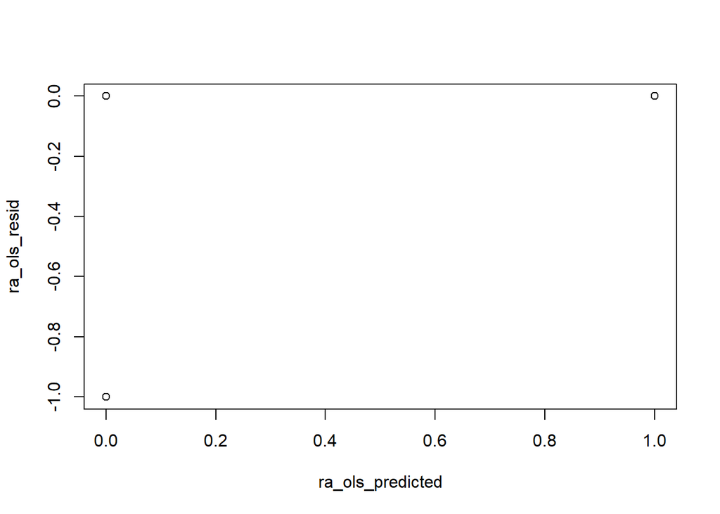

```r
plot(ra_ols_predicted, ra_ols_resid)
```

The OLS regression does not predict the test results well. This is also evidenced by the line in the ggplot, which doesn’t separate the positive and negative results well.

3. Using OLS

```r
ra_ols_coef <- coef(ra_ols)
rc_ols_intercept <- (0.5-ra_ols_coef[1])/(ra_ols_coef[2])
rc_ols_slope <- -(ra_ols_coef[3]/ra_ols_coef[2])
```

0.5 = ra_ols_coef[1] + ra_ols_coef[2]*temp + ra_ols_coef[3]*bp  
(0.5-ra_ols_coef[1])/(ra_ols_coef[2]ra_ols_coef[3]) = temp/ra_ols_coef[3] + bp/ra_ols_coef[2]  
temp = -(ra_ols_coef[3]/ra_ols_coef[2])bp + (0.5-ra_ols_coef[1])/(ra_ols_coef[2])

4. Using OLS

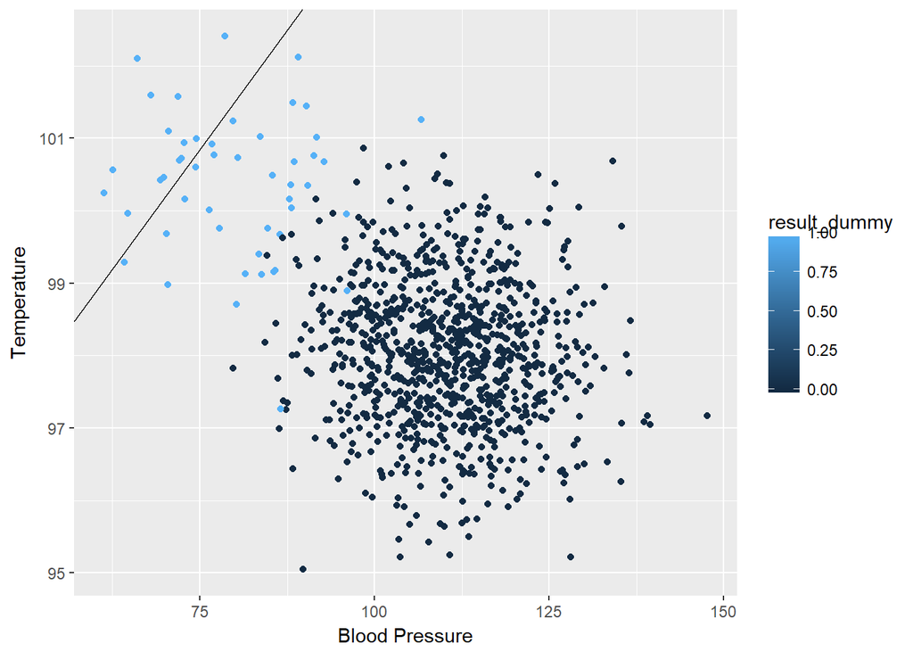

```r
ggplot(sick_data, aes(x = bp, y = temp)) +
  geom_point(aes(col = result_dummy)) +
  labs(x="Blood Pressure", y="Temperature") +
  geom_abline(intercept = rc_ols_intercept, slope = rc_ols_slope)
```

1. Using Logit

```r
ra_logit <- glm(sick_data$result_dummy ~ sick_data$temp + sick_data$bp, family = binomial)
summary(ra_logit)
```

```
##
## Call:
## glm(formula = sick_data$result_dummy ~ sick_data$temp + sick_data$bp,
##     family = binomial)
##
## Deviance Residuals:
##      Min        1Q    Median        3Q       Max
## -1.62332  -0.02253  -0.00462  -0.00093   3.02311
##
## Coefficients:
##                 Estimate Std. Error z value Pr(>|z|)
## (Intercept)    -199.3267    46.8077  -4.258 2.06e-05 ***
## sick_data$temp    2.3140     0.4923   4.700 2.60e-06 ***
## sick_data$bp     -0.3499     0.0638  -5.485 4.14e-08 ***
## ---
## Signif. codes:  0 '***' 0.001 '**' 0.01 '*' 0.05 '.' 0.1 ' ' 1
##
## (Dispersion parameter for binomial family taken to be 1)
##
##     Null deviance: 397.030  on 999  degrees of freedom
## Residual deviance:  53.837  on 997  degrees of freedom
## AIC: 59.837
##
## Number of Fisher Scoring iterations: 10
```

2. Using Logit

```r
ra_logit_fitted <- predict(ra_logit)
ra_logit_predicted <- ra_logit_fitted
ra_logit_predicted[ra_logit_fitted >= 0.5] <- 1
ra_logit_predicted[ra_logit_fitted < 0.5] <- 0
ra_logit_resid <- ra_logit_predicted - sick_data$result_dummy
print(summary(ra_logit_resid))
```

```
##    Min. 1st Qu.  Median    Mean 3rd Qu.    Max.
##  -1.000   0.000   0.000  -0.004   0.000   1.000
```

The logit model does much better than the ols model. The regression predicts the test results quite well, as is evident in the ggplot in part d.

3. Using Logit

```r
rc_logit_coef <- coef(ra_logit)
rc_logit_intercept <- -(rc_logit_coef[1]/rc_logit_coef[2])
rc_logit_slope <- -(rc_logit_coef[3]/rc_logit_coef[2])
```

ln(0.5/(1-0.5)) = rc_logit_coef[1] + rc_logit_coef[2]*temp + rc_logit_coef[3]*bp  
temp = -(rc_logit_coef[1]/rc_logit_coef[2]) - (rc_logit_coef[3]/rc_logit_coef[2])*bp

4. Using Logit

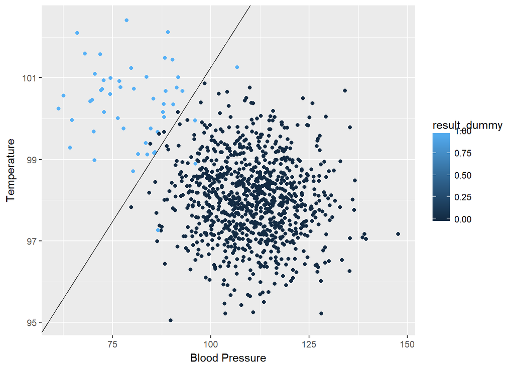

```r
ggplot(sick_data, aes(x = bp, y = temp)) +
  geom_point(aes(col = result_dummy)) +
  labs(x="Blood Pressure", y="Temperature") +
  geom_abline(intercept = rc_logit_intercept, slope = rc_logit_slope)
```

## Regularization/Selection Questions

```r
widget_data <- read.csv("widget_data.csv", header = TRUE)
```

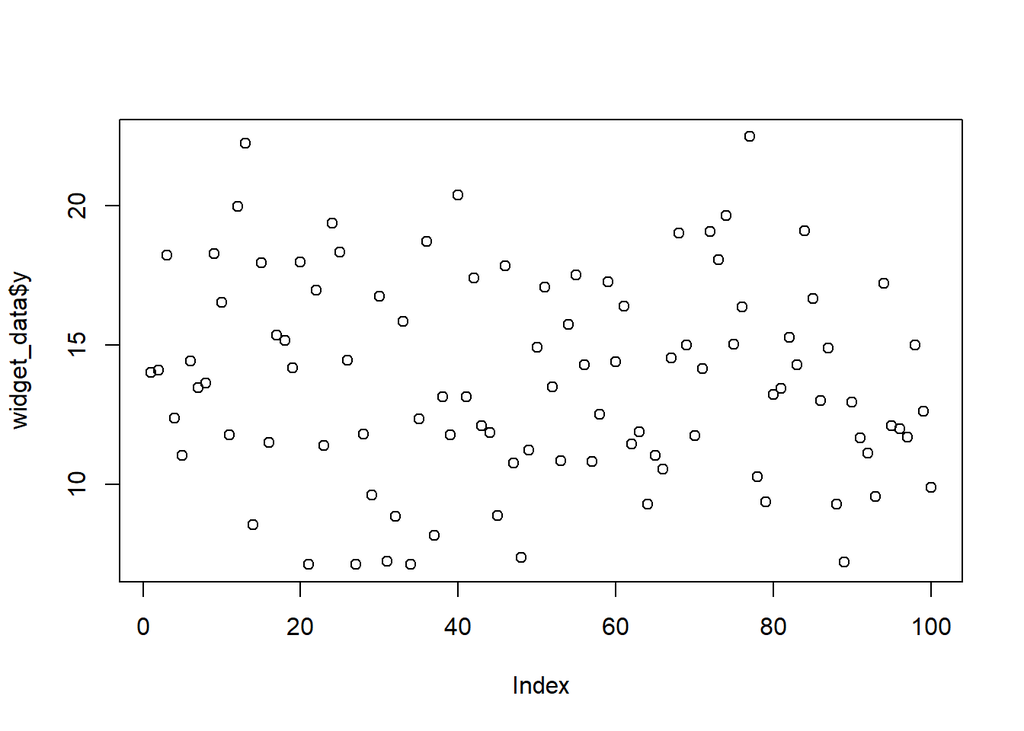

```r
plot(widget_data$y)
```

```r
library(glmnet)
grid <- 10^seq(2, -2, length = 100)
rb_x <- model.matrix(y~., widget_data)[ ,-1]
rb_y <- widget_data$y
ridge_mod <- glmnet(rb_x, rb_y, alpha = 0, lambda = grid)
```

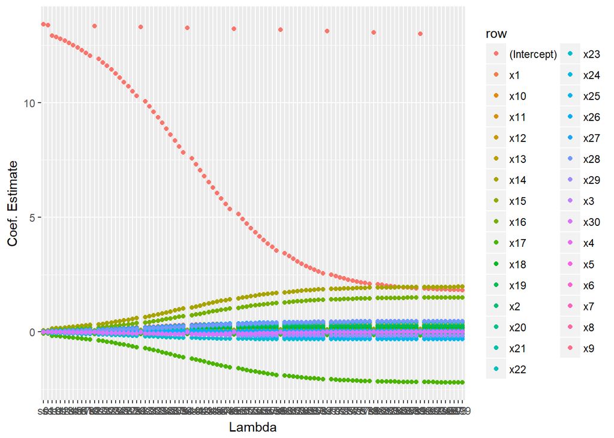

```r
ridge_result <- tidy(coef(ridge_mod))
ggplot(ridge_result, aes(x = column, y = value)) +
  geom_point(aes(col = row)) +
  labs(x="Lambda", y="Coef. Estimate")
```

```r
ridge_cv <- cv.glmnet(rb_x, rb_y, alpha = 0)
ridge_bestlambda <- ridge_cv$lambda.min
print(ridge_bestlambda)
```

```
## [1] 0.3410022
```

```r
ridge_mod_bestlambda <- glmnet(rb_x, rb_y, alpha = 0, lambda = 0.3107085)
print(coef(ridge_mod_bestlambda))
```

```
## 31 x 1 sparse Matrix of class "dgCMatrix"
##                      s0
## (Intercept)  3.17521189
## x1           0.15506300
## x2          -0.01910078
## x3           0.09945656
## x4           0.17413231
## x5           0.14151502
## x6           0.10150593
## x7           0.33778214
## x8          -0.03823309
## x9          -0.09730966
## x10          0.08021127
## x11          0.23259936
## x12          0.17387553
## x13          0.12787897
## x14          1.76526454
## x15          0.39494939
## x16          1.32081504
## x17         -1.94250211
## x18          0.19443285
## x19          0.26541460
## x20         -0.07175228
## x21          0.37832146
## x22         -0.15661836
## x23         -0.30789844
## x24         -0.09574364
## x25         -0.24043224
## x26          0.04780643
## x27          0.42452672
## x28          0.41752370
## x29         -0.15507903
## x30         -0.03747431
```

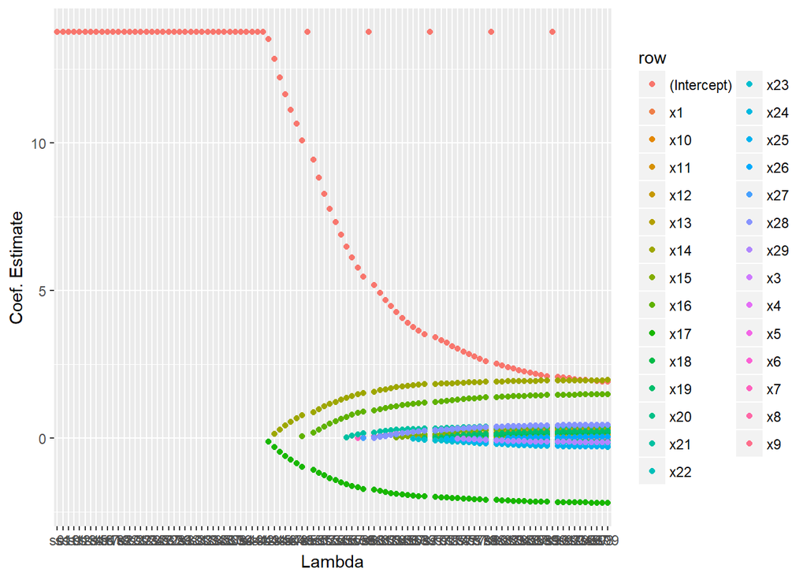

```r
lasso_mod <- glmnet(rb_x, rb_y, alpha = 1, lambda = grid)
lasso_result <- tidy(coef(lasso_mod))
ggplot(lasso_result, aes(x = column, y = value)) +
  geom_point(aes(col = row)) +
  labs(x="Lambda", y="Coef. Estimate")
```

```r
lasso_cv <- cv.glmnet(rb_x, rb_y, alpha = 1)
lasso_bestlambda <- lasso_cv$lambda.min
print(lasso_bestlambda)
```

```
## [1] 0.1906479
```

```r
lasso_mod_bestlambda <- glmnet(rb_x, rb_y, alpha = 1, lambda = 0.1737112)
print(coef(lasso_mod_bestlambda))
```

```
## 31 x 1 sparse Matrix of class "dgCMatrix"
##                      s0
## (Intercept)  3.59589507
## x1           .
## x2           .
## x3           .
## x4           .
## x5           .
## x6           .
## x7           0.24039337
## x8           .
## x9           .
## x10          .
## x11          0.03370297
## x12          .
## x13          .
## x14          1.81472842
## x15          0.10640283
## x16          1.19295540
## x17         -1.96179056
## x18          .
## x19          .
## x20          .
## x21          0.32145149
## x22          .
## x23         -0.04130842
## x24          .
## x25          .
## x26          .
## x27          0.22712692
## x28          0.23944526
## x29          .
## x30          .
```

6. The results from the two processes are similar.  
   The variables with non-zero coefs from the lasso roughly match the variables with significant coefs from ridge.  
   However, there are some variables from ridge with relatively higher coefs that lasso doesn’t include, such as x19.  
   The advantage of using lasso becomes apparant in that the less significant variables automatically get filtered out, allowing us to instantly identify the signficant variables calculated by our model.

## Classification Questions

```r
library(e1071)
pol_data <- read.csv("pol_data.csv", header = TRUE)
```

```r
pol_data$group_dummy <- pol_data$group == "Socialcrat"
pol_data$group_dummy[pol_data$group_dummy == TRUE] <- 1
pol_data$group_dummy[pol_data$group_dummy == FALSE] <- 0
# Create dummy variables first
# Socialcrat = 1
# Politicalist = 0

set.seed(666)
train_size <- floor(2/3 * nrow(pol_data))
train_index <- sample(seq_len(nrow(pol_data)), size = train_size)
pol_train <- pol_data[train_index, ]
pol_test <- pol_data[-train_index, ]
```

Data now split into pol_train (200 obs.) and pol_test (100 obs.) Uses seed 666.

2. First estimate using OLS model

```r
pol_ols <- lm(group_dummy ~ pol_margin + col_degree + house_income, data = pol_train)
summary(pol_ols)
```

```
##
## Call:
## lm(formula = group_dummy ~ pol_margin + col_degree + house_income,
##     data = pol_train)
##
## Residuals:
##      Min       1Q   Median       3Q      Max
## -0.63098 -0.19658 -0.01391  0.19274  0.70061
##
## Coefficients:
##                Estimate Std. Error t value Pr(>|t|)
## (Intercept)   1.580e+00  9.875e-02  16.002  < 2e-16 ***
## pol_margin   -4.420e-01  8.574e-02  -5.155 6.18e-07 ***
## col_degree    4.291e-01  9.139e-02   4.695 5.00e-06 ***
## house_income -1.650e-05  1.276e-06 -12.930  < 2e-16 ***
## ---
## Signif. codes:  0 '***' 0.001 '**' 0.01 '*' 0.05 '.' 0.1 ' ' 1
##
## Residual standard error: 0.259 on 196 degrees of freedom
## Multiple R-squared:  0.7363, Adjusted R-squared:  0.7323
## F-statistic: 182.4 on 3 and 196 DF,  p-value: < 2.2e-16
```

Now estimate using logit model

```r
pol_logit <- glm(group_dummy ~ pol_margin + col_degree + house_income, data = pol_train, family = binomial)
summary(pol_logit)
```

```
##
## Call:
## glm(formula = group_dummy ~ pol_margin + col_degree + house_income,
##     family = binomial, data = pol_train)
##
## Deviance Residuals:
##      Min        1Q    Median        3Q       Max
## -2.28262  -0.08710  -0.00155   0.05058   2.48499
##
## Coefficients:
##                Estimate Std. Error z value Pr(>|z|)
## (Intercept)   1.939e+01  4.056e+00   4.781 1.75e-06 ***
## pol_margin   -5.636e+00  2.385e+00  -2.363  0.01813 *
## col_degree    7.086e+00  2.471e+00   2.867  0.00414 **
## house_income -3.071e-04  6.689e-05  -4.591 4.40e-06 ***
## ---
## Signif. codes:  0 '***' 0.001 '**' 0.01 '*' 0.05 '.' 0.1 ' ' 1
##
## (Dispersion parameter for binomial family taken to be 1)
##
##     Null deviance: 276.759  on 199  degrees of freedom
## Residual deviance:  39.653  on 196  degrees of freedom
## AIC: 47.653
##
## Number of Fisher Scoring iterations: 8
```

3. First predict using OLS model

```r
pol_ols_predict <- predict(pol_ols, pol_test)
pol_ols_predict_final <- pol_ols_predict
pol_ols_predict_final[pol_ols_predict_final >= 0.5] <- 1
pol_ols_predict_final[pol_ols_predict_final < 0.5] <- 0
```

Now predict using logit model

```r
pol_logit_predict <- predict(pol_logit, pol_test)
pol_logit_predict_final <- pol_logit_predict
pol_logit_predict_final[pol_logit_predict_final >= 0.5] <- 1
pol_logit_predict_final[pol_logit_predict_final < 0.5] <- 0
```

```r
pol_resultcomps <- data.frame(pol_test$group_dummy, pol_ols_predict_final, pol_logit_predict_final)
colnames(pol_resultcomps) <- c("Real class", "OLS Prediction", "Logit Prediction")
print(pol_resultcomps)
```

```
##     Real class OLS Prediction Logit Prediction
## 3            1              1                1
## 6            1              1                1
## 7            1              0                0
## 8            1              1                1
## 13           1              1                1
## 15           1              1                1
## 20           1              1                1
## 21           1              1                1
## 25           1              1                1
## 34           1              1                1
## 35           1              1                1
## 43           1              1                1
## 45           1              1                1
## 47           1              1                1
```

[output cut: 86 more lines]

Both models seem to do a good job with the predictions.